# Администрирование локальных сетей

Лабораторная работа №14

Илья Колонтырский

Российский университет дружбы народов, Москва, Россия

09.05.2026

# Цели и задачи работы

## Цель лабораторной работы

Настроить взаимодействие через сеть провайдера посредством статической маршрутизации:

- локальной сети организации;
- сети основного здания в **42-м квартале Москвы**;
- сети общежития;
- сети филиала в **г. Сочи**.

## Задачи

- Настроить VLAN и trunk-соединения в сети провайдера.
- Настроить подинтерфейсы с инкапсуляцией **802.1Q**.
- Добавить статические маршруты между удалёнными сетями.
- Настроить IP-адресацию рабочих станций.
- Проверить связность командами **ping**, **tracert** и **show ip route**.

# Топология и адресный план

## Общая структура сети

- Центральная площадка: сеть **10.128.0.0/16**.
- Основное здание в 42-м квартале: сеть **10.129.0.0/16**.
- Филиал в Сочи: сеть **10.130.0.0/16**.
- Связь между площадками выполняется через сеть провайдера.
- Для маршрутизации используются статические маршруты.

## Общая схема сети

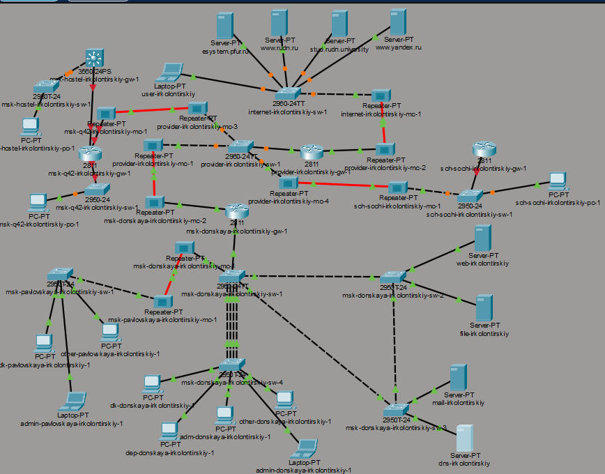

Общая топология сети организации, провайдера и удалённых площадок

# Настройка сети провайдера

## VLAN на коммутаторе провайдера

На коммутаторе **provider-irkolontirskiy-sw-1** были настроены trunk-порты и созданы VLAN:

- **VLAN 5** — канал до здания в 42-м квартале;
- **VLAN 6** — канал до филиала в Сочи.

Интерфейсы **FastEthernet0/3** и **FastEthernet0/4** переведены в режим trunk.

## Настройка VLAN провайдера

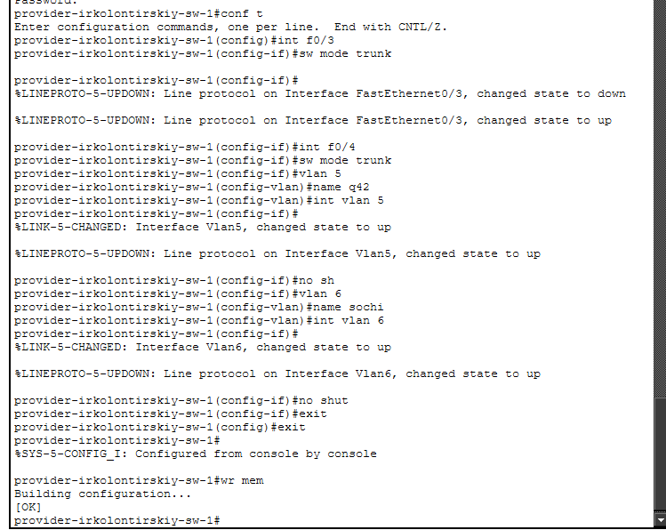

Настройка trunk-портов и VLAN 5, VLAN 6 на коммутаторе провайдера

# Центральная площадка

## Настройка центрального маршрутизатора

На маршрутизаторе **msk-donskaya-irkolontirskiy-gw-1** были созданы подинтерфейсы:

- **FastEthernet0/1.5** — VLAN 5, канал до 42-го квартала;
- **FastEthernet0/1.6** — VLAN 6, канал до Сочи.

Добавлены статические маршруты:

```
ip route 10.129.0.0 255.255.0.0 10.128.255.2
ip route 10.130.0.0 255.255.0.0 10.128.255.6
```

## Центральный маршрутизатор

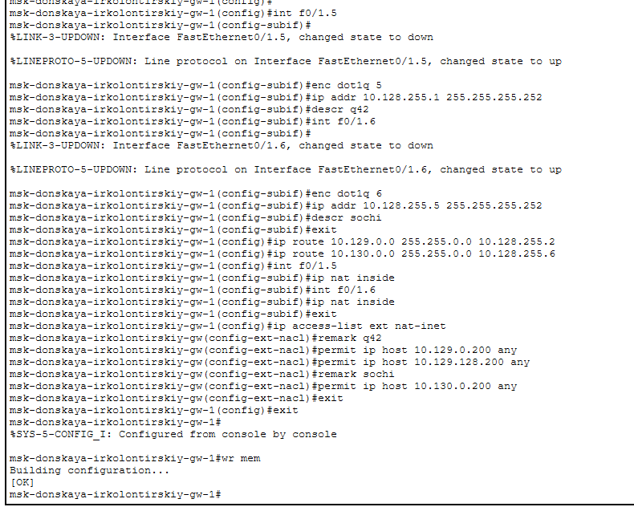

Настройка подинтерфейсов, статических маршрутов и ACL на центральном маршрутизаторе

# Сеть 42-го квартала

## Маршрутизатор 42-го квартала

На маршрутизаторе **msk-q42-irkolontirskiy-gw-1** были настроены:

- **FastEthernet0/1.5** — подключение к центральной площадке через VLAN 5;
- **FastEthernet0/0.201** — основная сеть 42-го квартала;
- **FastEthernet1/0.202** — сеть управления;
- маршрут по умолчанию через **10.128.255.1**.

## Настройка маршрутизатора 42-го квартала

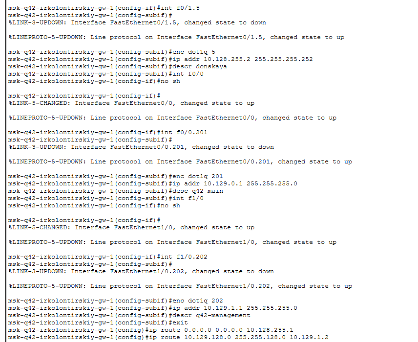

Настройка маршрутизатора здания в 42-м квартале

## Коммутатор 42-го квартала

На коммутаторе **msk-q42-irkolontirskiy-sw-1** были выполнены настройки:

- порт **FastEthernet0/24** переведён в режим trunk;
- порт **FastEthernet0/1** переведён в режим access;
- для рабочей станции назначен **VLAN 201**;
- создан VLAN **q42-main**.

## Настройка VLAN 201

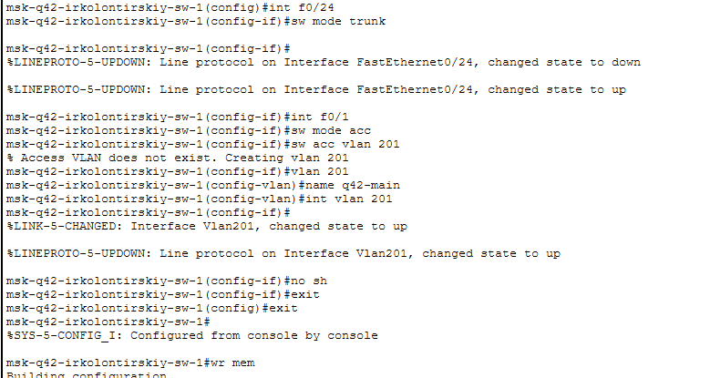

Настройка VLAN 201 и access-порта на коммутаторе 42-го квартала

## IP-адресация ПК 42-го квартала

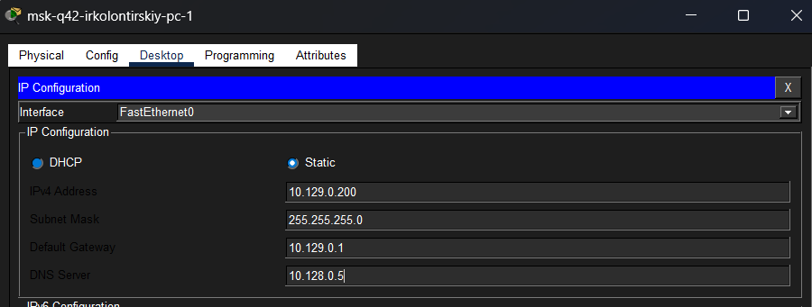

Статическая настройка IP-адреса рабочей станции в сети 42-го квартала

# Сеть общежития

## Маршрутизирующее устройство общежития

На устройстве **msk-hostel-irkolontirskiy-gw-1** были настроены:

- **VLAN 202** — подключение к управленческому сегменту 42-го квартала;
- **VLAN 301** — основная сеть общежития;
- IP-маршрутизация;
- маршрут по умолчанию через **10.129.1.1**.

## Настройка маршрутизатора общежития

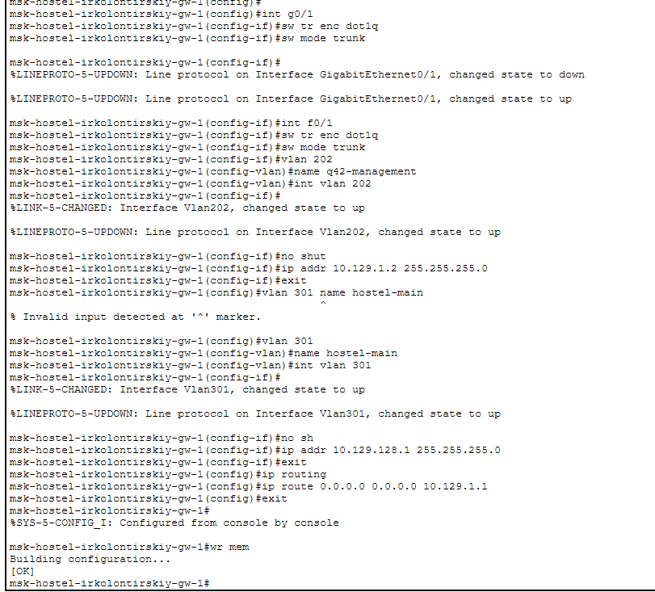

Настройка VLAN 202, VLAN 301 и маршрута по умолчанию на маршрутизаторе общежития

## Коммутатор общежития

На коммутаторе **msk-hostel-irkolontirskiy-sw-1** были выполнены настройки:

- **GigabitEthernet0/1** — trunk-порт;
- **FastEthernet0/1** — access-порт;
- рабочая станция подключена к **VLAN 301**;
- VLAN получил имя **hostel-main**.

## Настройка VLAN 301

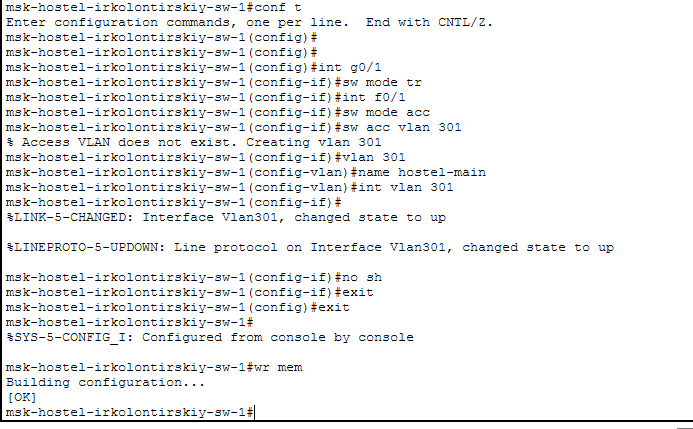

Настройка trunk-порта и VLAN 301 на коммутаторе общежития

## IP-адресация ПК общежития

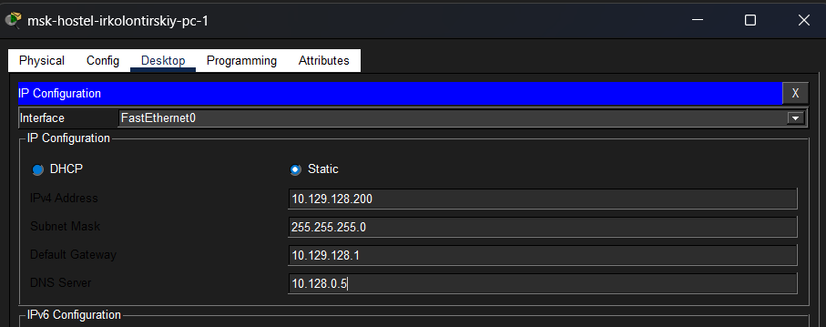

Статическая настройка IP-адреса рабочей станции общежития

# Филиал в Сочи

## Коммутатор филиала

На коммутаторе **sch-sochi-irkolontirskiy-sw-1** были настроены:

- **FastEthernet0/23** и **FastEthernet0/24** в режиме trunk;
- **VLAN 6** для связи через провайдера;
- **VLAN 401** для основной сети филиала;
- access-порт для рабочей станции.

## Настройка коммутатора филиала

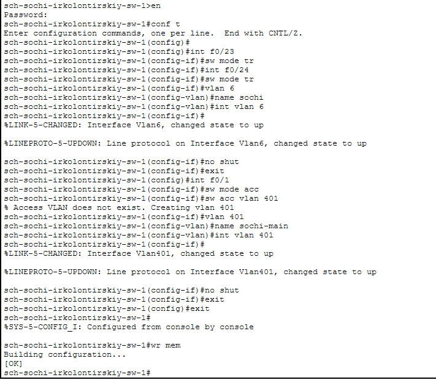

Настройка VLAN 6, VLAN 401 и портов на коммутаторе филиала в Сочи

## Маршрутизатор филиала

На маршрутизаторе **sch-sochi-irkolontirskiy-gw-1** были настроены подинтерфейсы:

- **FastEthernet0/0.6** — связь с провайдером;
- **FastEthernet0/0.401** — основная сеть филиала;
- **FastEthernet0/0.402** — сеть управления.

Маршрут по умолчанию направлен через **10.128.255.5**.

## Настройка маршрутизатора филиала

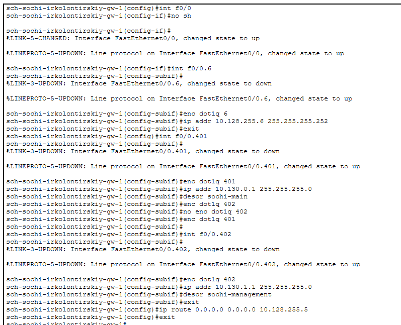

Настройка подинтерфейсов и маршрута по умолчанию на маршрутизаторе филиала в Сочи

## IP-адресация ПК филиала

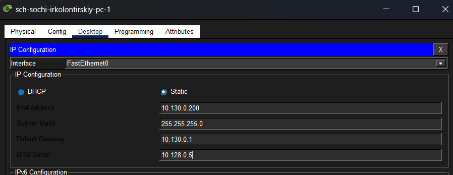

Статическая настройка IP-адреса рабочей станции филиала в Сочи

# Проверка работоспособности

## Проверка доступности узлов

С административной рабочей станции центральной площадки была проверена доступность:

| Узел | IP-адрес | Результат |
| --- | --- | --- |
| ПК 42-го квартала | 10.129.0.200 | Доступен |
| ПК общежития | 10.129.128.200 | Доступен |
| ПК филиала в Сочи | 10.130.0.200 | Доступен |

Во всех случаях потери пакетов составили **0%**.

## Проверка ping

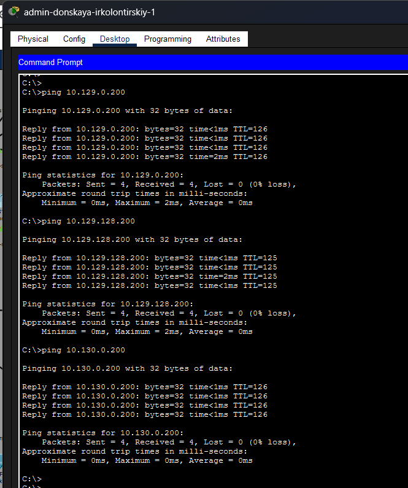

Проверка доступности удалённых рабочих станций с административного ПК

## Проверка маршрутов tracert

Команда **tracert** показала прохождение трафика через ожидаемые промежуточные устройства:

- до **10.129.0.200** — через маршрутизатор 42-го квартала;
- до **10.129.128.200** — через маршрутизатор 42-го квартала и устройство общежития;
- до **10.130.0.200** — через маршрутизатор филиала в Сочи.

## Результат tracert

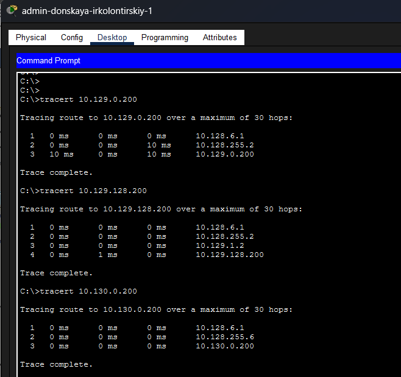

Проверка маршрутов прохождения трафика до удалённых сетей

# Таблицы маршрутизации

## Таблица маршрутизации центрального маршрутизатора

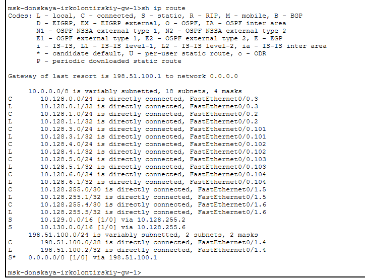

Таблица маршрутизации центрального маршрутизатора

## Таблица маршрутизации 42-го квартала

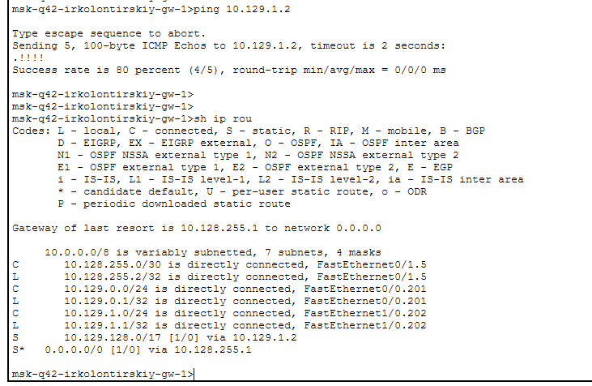

Проверка связи с общежитием и таблица маршрутизации маршрутизатора 42-го квартала

## Таблица маршрутизации общежития

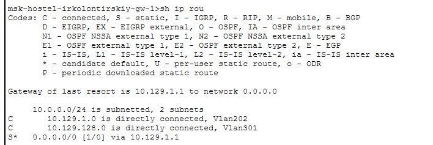

Таблица маршрутизации устройства общежития

## Таблица маршрутизации филиала в Сочи

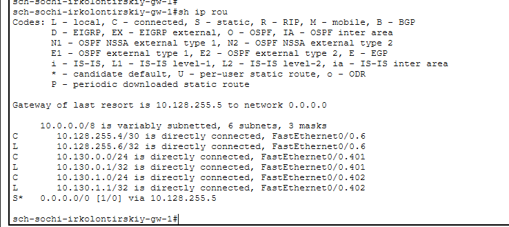

Таблица маршрутизации маршрутизатора филиала в Сочи

## Вывод

Статическая маршрутизация между центральной сетью организации, сетью 42-го квартала, сетью общежития и филиалом в Сочи настроена успешно.

Проверка командами **ping**, **tracert** и **show ip route** подтвердила:

- доступность удалённых рабочих станций;
- корректное прохождение трафика через сеть провайдера;
- наличие необходимых маршрутов в таблицах маршрутизации;
- работоспособность взаимодействия между всеми настроенными площадками.